# Implementation of an analysis tool for travel mode detection in R

### 2.4 Adding Geographic Context

```r
##spatial join: attribute nearest route

background_data <- rbind(roads, rails, boats) #merge the three datasets together
data <- st_join(data, background_data, join = st_nearest_feature)

data$OBJEKTART <- as.factor(data$OBJEKTART)
data_smry_context <- data |>
  group_by(segment_id) |>
  summarise(
            nearest_route = levels(OBJEKTART)[which.max(table(OBJEKTART))],
            percentage_nearest_route = max(table(OBJEKTART)) / length(OBJEKTART) * 100
) |>
  as_tibble() |>
  select(-c("geometry"))
```

According to Gschwend (2015) movement patterns are mostly quantified on the basis of geometric properties and the arrangement of the fixes, while the geographic environment surrounding the movement is often neglected, however would provide useful semantics insights. Hence, using external information can increase the performance of the used algorithms substantially (Sadeghian). As the exploratory data analysis of the movement parameters has shown hardly distinguishable features, we wanted to add this approach to our analysis. Hence, as described in chapter 2.1, several feature classes of the swissTLM3D dataset were used and all roads, rails and boat-routes were merged into one background dataset. Next, a spatial join was performed, attributing every fix of the POSMO data to its nearest feature, as visualized in figure 4 for an exemplary day. Lastly, every segment was assigned the feature, which was attributed to most of the points of said segment, the same way it was done for the POSMO travel mode.

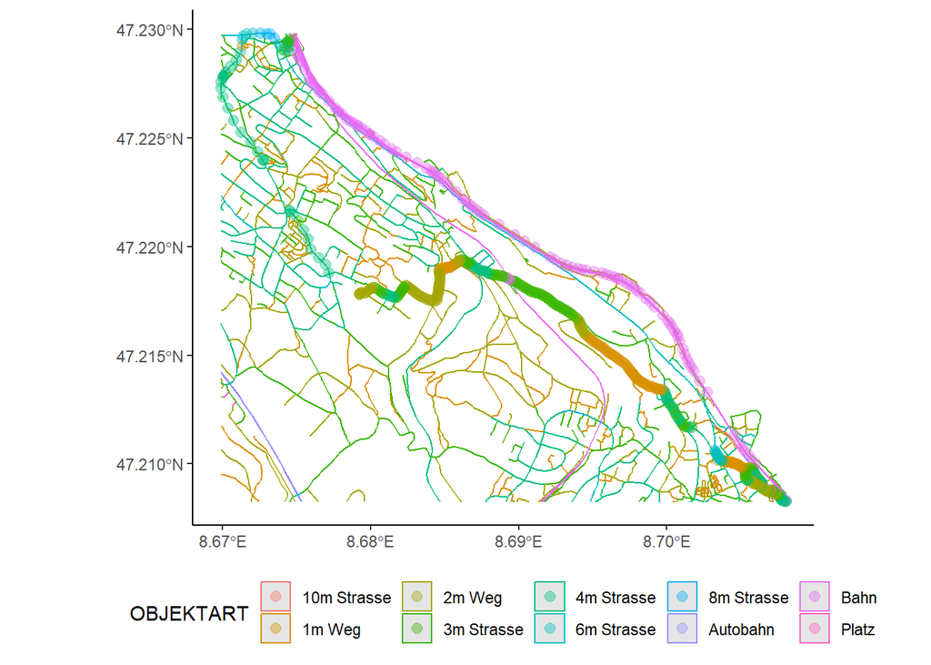

*Figure 4: the spatial join of the POSMO data (point) to the nearest feature of roads, rails and boat lines*

```r
data_01 <- data |>
  filter(as.Date(datetime) == "2023-04-18") #select example day

bbox <- st_bbox(data_01) #produce a bounding box with that day
clipped_background <- st_crop(background_data, bbox) #cut backround to that bounding box

ggplot()+ #visualize
  geom_sf(data=clipped_background, aes(color=OBJEKTART))+
  geom_sf(data=data_01, alpha=0.4, size=2.5, aes(color=OBJEKTART))+
  theme_classic()+
  theme(legend.position = "bottom")
```

```r
##stop-buffer calculations:

stops <- stops |>
  rename(stop_type = OBJEKTART)

stops_buffer <- st_buffer(stops, 75) #calculating buffer of 75m around every stop
stop_join <- st_join(data, stops_buffer, join = st_within) #spatial join with POSMO data

first_point <- stop_join |> # a vector is produced, containing the information for the first point of every segment
  group_by(segment_id) |>
  slice_head() |> #first point is chosen
  pull(stop_type, segment_id) #information about stops is saved

last_point <- stop_join |> #same for last point of every segment
  group_by(segment_id) |>
  slice_tail() |>
  pull(stop_type, segment_id)

##merging all parameters:

data_smry_context <- data_smry_context |>
  cbind(first_point, last_point)

data_class <- left_join(data_smry, data_smry_context, by = "segment_id")

##export for classification (so swisstlm3d has not to be loaded every time)

write.csv(data_class, "output_files/data_class.csv")
```

Further, the feature class TLM_HALTESTELLE of swissTLM3D containing bus, train and boat stops was used as well. A buffer of 75 meters was calculated around every stop and a spatial join was performed for fixes within these buffers. Next, for every segment the information, if the first and the last point were within a stop-buffer was saved additionally for further analysis. Finally, the moving parameters were merged with the geographical context of the segments into a dataset ready for travel mode classification.

### 2.5 Travel Mode Detection

```r
##travel mode detection:

data_class$travel_mode_det <- NA

data_class <- data_class |>
  mutate(
    travel_mode_det = case_when(
      nearest_route == "Bahn" | max_speed > 44.44 ~ "Train",
      nearest_route == "Tram" ~ "Tram",
      nearest_route %in% c("Autofaehre", "Personenfaehre") ~ "Boat",
      first_point == "Haltestelle Schiff" & last_point == "Haltestelle Schiff" ~ "Boat",
      (first_point %in% c("Haltestelle Bahn", "Haltestelle Bus")) & (last_point %in% c("Haltestelle Bus", "Haltestelle Bahn")) ~ "Bus",
      max_speed > 12.5 | max_acc > 0.3 ~ "Car",
      mean_speed > 1.94 | max_speed > 5  ~ "Bike",
      TRUE ~ "Walk"
    )
  )
```

Several studies suggest, first separating non-motorized and motorized vehicles and then split up these sub-categories in a second classification step (Zhang, ?). Zhang et. al (2012), for example classified pedestrian, bicylce and motorized vehicles in a first step by using speed, acceleration and heading related parameters. Then, in second step supervised learing algorithms are used to split up motorized journeys to car, bus, trams and trains. However, the moving parameters of our training data seemed not to differ sicnificantly enough, to split up bicycle from Tram, Boat or even Bus journeys. Hence, we decided to use the context information for a first classification and added moving parameters only where they were clearly distinguishable. In that way, train (segment closest to train rails or max speed > 160km/h), tram (segment closest to tram rails), boat (segment closest to boat line or first and last point in boat stop buffer) and bus (first and last stop in bus or train stop buffer) trajectories were classified. This was done in the exact same order, so that trajectories classified as train were not able to be classified again as bus. Next, trajectories with a maximal speed over 45 km/h or maximal acceleration over 0.3 m/s^2 were classified as car segments. Then, segments with a main speed higher than 7km/h or maximal speed over 18km/h were classified as bike rides. And lastly, the remaining segments, which thus had to have a main speed lower than 7km/h were classified as walks.